# Fifa 18 - How age and nationality make a difference in Fifa

Capstone by Daniel Lopez

```python
import pandas as pd
import numpy as np
import matplotlib.pyplot as plt
%matplotlib inline
```

- About the dataset
- Summary
- Hypothesis
- Preparing the data
- Quick look at soccer player ages
- Co-relate between age and overall rating
- Co-relate between age and potential
- Co-relate between age and wage
- Co-relate between age and nationality
- Conclusion

# About the dataset

```python
df = pd.read_csv('CompleteDataset.csv', low_memory=False)
```

The [Fifa 18 Complete Player Dataset](https://www.kaggle.com/thec03u5/fifa-18-demo-player-dataset) features in-game attributes of all the players in the video game Fifa 18 by EA. The data is scraped from the website https://sofifa.com by extracting the Player personal data and Player Ids and then the playing and style statistics. Each attribute has been assigned by EA based off of each players performances from previous years. This dataset contains approximately 18,000 players with 75 attributes each.

### Acknowledgements

This dataset was provided by Aman Shrivastava on [kaggle.com](https://www.kaggle.com/).

# Summary

It is generally accepted that a young player has a lot of potential and as he gets older he becomes a better soccer player. After a few golden years at his peak performance, that player eventually gets older and his skills deteriorate. I want to know (on average) which ages are the "golden years" and how much of an impact age has when it comes to EA's rankings for player's potential. Once the 'Golden years' have been established, I want to compare the average wage by age to the Golden years and see if there is a connection.

Also, while we are taking a look at age and potential. I want to explore the average age and the average potential of each nation since these two factors may have an impact of future performances for international teams. I will also be paying close attention to the number of players each nation has since some nations may not have a large enough sample group to be useful and there may be a corellation between the number of players and a countries average potential.

# Hypothesis

I predict that the relationship between age and overall score will be a natural bell curve with players overall rankings being low at younger ages and peaking around 25 years of age then beginning to slope back down. I assume age is a direct factor in EA's potential rankings so I expect that the average potential for each age group will be highest at the youngest ages and steadily decrease with age. I predict the average wage a player makes based on age will be very similar to the relationship between age and overall score.

If soccer has been a part of a countries culture for a long time then more people will be playing it. If more people are playing the sport then more people will be playing professional from that country around the world. As the sport naturally progresses it becomes more difficult for players to become a professional, therefor increasing the quality of the players from the country. I believe EA keeps this in mind when assigning potential rankings so I predict that the nations with the most amount of players will have the highest potential even if their average age may be lower than others.

# Preparing the data

```python
df.columns
```

```
Index(['Unnamed: 0', 'Name', 'Age', 'Photo', 'Nationality', 'Flag', 'Overall',
       'Potential', 'Club', 'Club Logo', 'Value', 'Wage', 'Special',
       'Acceleration', 'Aggression', 'Agility', 'Balance', 'Ball control',
       'Composure', 'Crossing', 'Curve', 'Dribbling', 'Finishing',
       'Free kick accuracy', 'GK diving', 'GK handling', 'GK kicking',
       'GK positioning', 'GK reflexes', 'Heading accuracy', 'Interceptions',
       'Jumping', 'Long passing', 'Long shots', 'Marking', 'Penalties',
       'Positioning', 'Reactions', 'Short passing', 'Shot power',
       'Sliding tackle', 'Sprint speed', 'Stamina', 'Standing tackle',
       'Strength', 'Vision', 'Volleys', 'CAM', 'CB', 'CDM', 'CF', 'CM', 'ID',
       'LAM', 'LB', 'LCB', 'LCM', 'LDM', 'LF', 'LM', 'LS', 'LW', 'LWB',
       'Preferred Positions', 'RAM', 'RB', 'RCB', 'RCM', 'RDM', 'RF', 'RM',
       'RS', 'RW', 'RWB', 'ST'],
      dtype='object')
```

**We currently have a total of 75 columns per player and we don't need all of them so lets reduce the dataset to only what is necessary.**

```python
necessary_columns = [
    'Age',
    'Nationality',
    'Overall',
    'Potential',
    'Wage',
    'Value'
]
df = pd.DataFrame(df, columns=necessary_columns)
df.head()
```

|  | Age | Nationality | Overall | Potential | Wage | Value |
| --- | --- | --- | --- | --- | --- | --- |
| 0 | 32 | Portugal | 94 | 94 | €565K | €95.5M |
| 1 | 30 | Argentina | 93 | 93 | €565K | €105M |
| 2 | 25 | Brazil | 92 | 94 | €280K | €123M |
| 3 | 30 | Uruguay | 92 | 92 | €510K | €97M |
| 4 | 31 | Germany | 92 | 92 | €230K | €61M |

**The "Wage" and "Value" columns are currently a string formatted as a money value. Let's make a function that will reformat these values as a float.**

```python
def extract_value_from(value):
    out = value.replace('€', '')
    if 'M' in out:
        out = float(out.replace('M', ''))*1000000
    elif 'K' in value:
        out = float(out.replace('K', ''))*1000
    return float(out)

df['Wage'] = df['Wage'].apply(lambda x: extract_value_from(x))
df['Wage'] = df['Wage'].apply(lambda x: x/1000)
df['Value'] = df['Value'].apply(lambda x: extract_value_from(x))
df['Value'] = df['Value'].apply(lambda x: x/1000000)
```

As of right now, a players potential score shows what their overall score can reach after training a player in career mode. We want this number to reflect how much potential growth there is instead of the final value. Let's reassign this value to show those potential points.

```python
df['Potential'] = df['Potential'] - df['Overall']
df.head()
```

|  | Age | Nationality | Overall | Potential | Wage | Value |
| --- | --- | --- | --- | --- | --- | --- |
| 0 | 32 | Portugal | 94 | 0 | 565.0 | 95.5 |
| 1 | 30 | Argentina | 93 | 0 | 565.0 | 105.0 |
| 2 | 25 | Brazil | 92 | 2 | 280.0 | 123.0 |
| 3 | 30 | Uruguay | 92 | 0 | 510.0 | 97.0 |
| 4 | 31 | Germany | 92 | 0 | 230.0 | 61.0 |

**Lets take a look and see what datatypes we are working with and if we have any null items.**

```python
df.info()
```

```
<class 'pandas.core.frame.DataFrame'>
RangeIndex: 17981 entries, 0 to 17980
Data columns (total 6 columns):
Age            17981 non-null int64
Nationality    17981 non-null object
Overall        17981 non-null int64
Potential      17981 non-null int64
Wage           17981 non-null float64
Value          17981 non-null float64
dtypes: float64(2), int64(3), object(1)
memory usage: 842.9+ KB
```

**We are able to see that all 17,981 players have values for Age, Nationality, Overall, Potential, Wage, and Value.**

# Quick look at soccer player ages

Before we start let's take a look at all the ages of the Fifa 18 players.

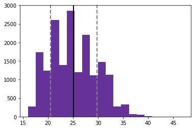

```
count    17981.000000
mean        25.144541
std          4.614272
min         16.000000
25%         21.000000
50%         25.000000
75%         28.000000
max         47.000000
Name: Age, dtype: float64
```

```python
player_ages = df['Age']
#Compute the mean and standard deviation and plot them as vertical lines on the histogram.
plt.hist(player_ages, bins=20, color='rebeccapurple')
# Add a vertical line at the mean.
plt.axvline(player_ages.mean(), color='black', linestyle='solid', linewidth=2)
# Add a vertical line at one standard deviation above the mean.
plt.axvline(player_ages.mean() + norm3.std(), color='grey', linestyle='dashed', linewidth=2)
# Add a vertical line at one standard deviation below the mean.
plt.axvline(player_ages.mean()-norm3.std(), color='grey', linestyle='dashed', linewidth=2)
plt.show()
player_ages.describe()
```

### What this means

We can see that the average age of all the players is approximately 25 years old with the youngest player being 16 and the oldest being 47. 25% of all values are less than that value. 25% of players are less than 21 years of age. 50% of players are less than 25 years old. 75% of players are less than 28 years old. STD stands for standard deviation which is a measurement of varience for data. A larger value means that the values lie far away from the mean, while a smaller value means that values lie closer together.

# Co-relate between age and overall rating

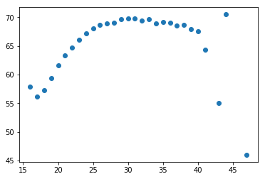

```python
df_age_overall = df.copy()
average_overall_by_age = df_age_overall.groupby('Age', as_index=False)['Overall'].mean()
plt.scatter(average_overall_by_age['Age'], average_overall_by_age['Overall'])
plt.show()
```

# Co-relate between age and potential

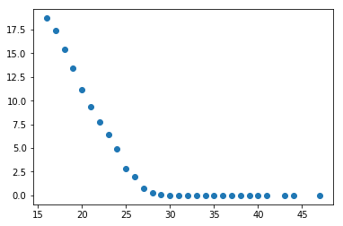

```python
df_age_potential = df.copy()
potential_by_age = df_age_potential.groupby('Age', as_index=False)['Potential'].mean()
plt.scatter(potential_by_age['Age'], potential_by_age['Potential'])
plt.show()
```

# Co-relate between age and wage

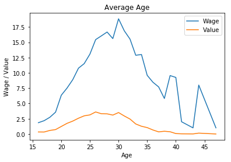

| Age | Wage | Value |
| --- | --- | --- |
| 16 | 1.846154 | 0.331154 |
| 17 | 2.174419 | 0.322519 |
| 18 | 2.729167 | 0.578810 |
| 19 | 3.567820 | 0.717844 |
| 20 | 6.338956 | 1.228711 |
| 21 | 7.503110 | 1.737815 |
| 22 | 8.878399 | 2.107054 |
| 23 | 10.761119 | 2.577034 |
| 24 | 11.506747 | 2.967762 |
| 25 | 13.065046 | 3.122208 |
| 26 | 15.435940 | 3.602691 |
| 27 | 16.045139 | 3.310399 |
| 28 | 16.672693 | 3.293092 |
| 29 | 15.601249 | 3.090250 |
| 30 | 18.838308 | 3.504726 |
| 31 | 16.874814 | 2.945589 |
| 32 | 15.515810 | 2.440899 |
| 33 | 12.871961 | 1.638630 |
| 34 | 13.000000 | 1.264320 |
| 35 | 9.591623 | 1.043665 |
| 36 | 8.463235 | 0.655110 |
| 37 | 7.695652 | 0.345652 |
| 38 | 5.805556 | 0.447639 |
| 39 | 9.550000 | 0.363500 |
| 40 | 9.250000 | 0.069375 |
| 41 | 2.000000 | 0.026667 |
| 43 | 1.000000 | 0.010000 |
| 44 | 8.000000 | 0.140000 |
| 47 | 1.000000 | 0.000000 |

```python
df_age_wage = df.copy()
wage_by_age = df_age_wage.groupby(['Age'])['Wage'].mean()
value_by_age = df_age_wage.groupby(['Age'])['Value'].mean()
wage_and_value = pd.concat([wage_by_age, value_by_age], axis=1)

axis = wage_and_value.plot()
axis.set_ylabel('Wage / Value')
axis.set_title('Average Age')
plt.show()
wage_and_value
```

# Co-relate between age and nationality

```python
df_nationality = df.copy()
column_total_players = df_nationality.groupby(['Nationality']).agg({'Nationality': 'count'})
column_avg_potential = df_nationality.groupby(['Nationality']).agg({'Potential': 'mean'})
df_nationality = df_nationality.groupby(['Nationality']).agg({'Age': 'mean'})
df_nationality['Number of Players'] = column_total_players
df_nationality['Average Potential'] = column_avg_potential
df_nationality.head(10)
```

| Nationality | Age | Number of Players | Average Potential |
| --- | --- | --- | --- |
| Afghanistan | 22.000000 | 3 | 10.000000 |
| Albania | 24.685714 | 35 | 4.514286 |
| Algeria | 26.543860 | 57 | 2.789474 |
| Angola | 25.600000 | 15 | 4.066667 |
| Antigua & Barbuda | 22.400000 | 5 | 8.200000 |
| Argentina | 25.932642 | 965 | 4.693264 |
| Armenia | 26.071429 | 14 | 3.714286 |
| Australia | 24.312775 | 227 | 5.744493 |
| Austria | 24.515038 | 266 | 5.293233 |
| Azerbaijan | 25.000000 | 7 | 4.714286 |

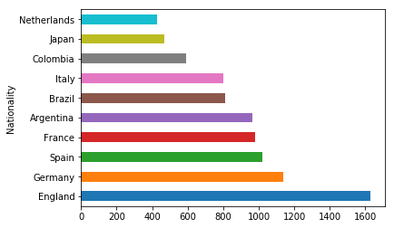

```python
nations_with_most_players = df_nationality['Number of Players'].sort_values(ascending=False).head(10)
nations_with_most_players.plot(kind="barh")
plt.show()
```

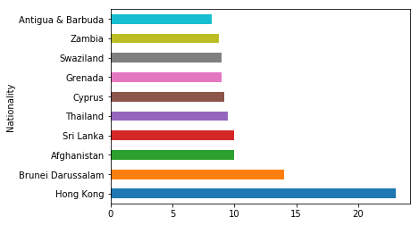

```python
nations_with_most_potential = df_nationality['Average Potential'].sort_values(ascending=False).head(10)
nations_with_most_potential.plot(kind="barh")
plt.show()
```